# Colgate vs Crest

Antonio Romero Mtnez-Eiroa

19/11/2020

### Carga de librerías

Cargamos las librerias necesarias para realizar el trabajo.

```r
library(readxl)
library(openxlsx)
library(skimr)
library(fpp2)
library(ggplot2)
library(zoo)
library(ggfortify)
library(tseries)
library(forecast)
library(xts)
library(readr)
library(tidyverse)
library(dplyr)
library(TSA)
library(Hmisc)
library(astsa)
library(tsoutliers)
library(normtest)
```

### Carga de datos

Importamos los datos desde un archivo en formato Excel.

```r
data <- read_excel('data.xlsx')
```

### Tratamiento de datos

Añadimos una columna que reuna el año y la semana y eliminamos las dos columnas originales.

```r
data$Date <- as.Date(paste(data$Year, data$Week, 1, sep = "-"), "%Y-%U-%u")
data <- dplyr::select(data, -Year, -Week)
```

Realizamos un análisis previo de los datos.

Data summary

| Name | data |
| --- | --- |
| Number of rows | 276 |
| Number of columns | 3 |
| _______________________ |  |
| Column type frequency: |  |
| Date | 1 |
| numeric | 2 |
| ________________________ |  |
| Group variables | None |

**Variable type: Date**

| skim_variable | n_missing | complete_rate | min | max | median | n_unique |
| --- | --- | --- | --- | --- | --- | --- |
| Date | 0 | 1 | 1958-01-06 | 1963-04-22 | 1960-08-25 | 276 |

**Variable type: numeric**

| skim_variable | n_missing | complete_rate | mean | sd | p0 | p25 | p50 | p75 | p100 | hist |
| --- | --- | --- | --- | --- | --- | --- | --- | --- | --- | --- |
| Crest | 0 | 1 | 0.26 | 0.13 | 0.05 | 0.13 | 0.25 | 0.37 | 0.53 | ▇▅▃▇▂ |
| Colgate | 0 | 1 | 0.31 | 0.07 | 0.16 | 0.26 | 0.31 | 0.36 | 0.50 | ▂▇▇▅▁ |

Dividimos el data frame en dos, uno para Colgate y otro para Crest miestras los convertimos en series temporales.

```r
xColgate <- ts(data$Colgate, start = 1958,frequency = 52)
xCrest <- ts(data$Crest, start = 1958, frequency = 52)
```

Graficamos las series

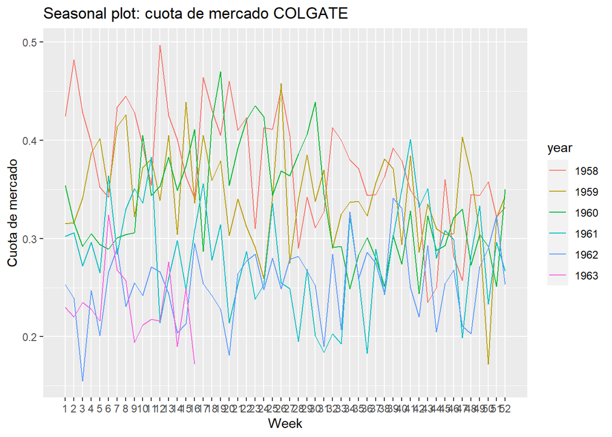

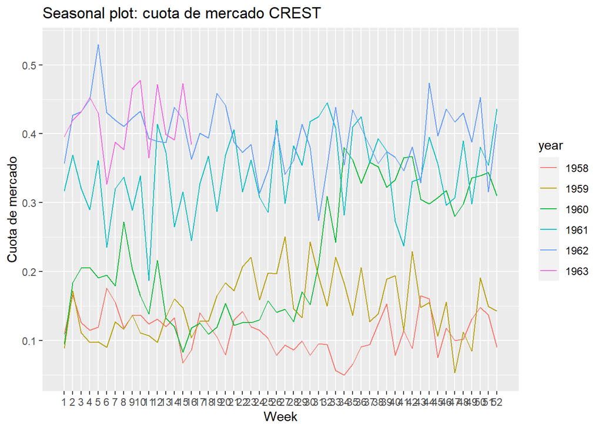

Convertimos a formato zoo.

```r
zColgate <- as.zoo(xColgate)
zCrest <- as.zoo(xCrest)
```

Observamos gráficamente ambas series.

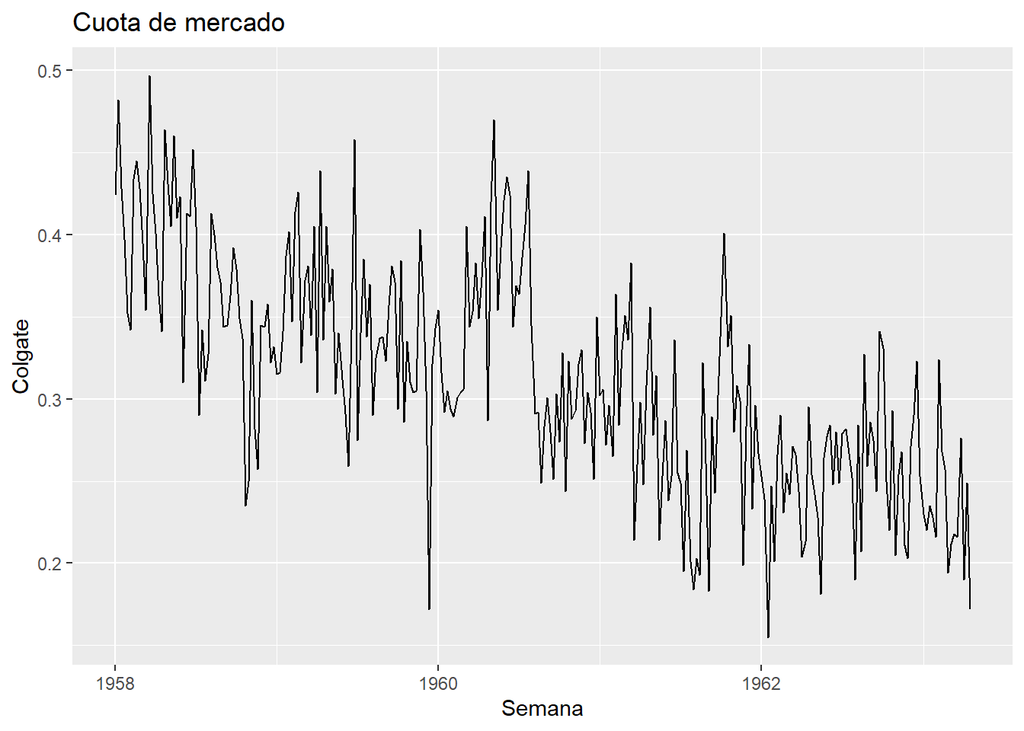

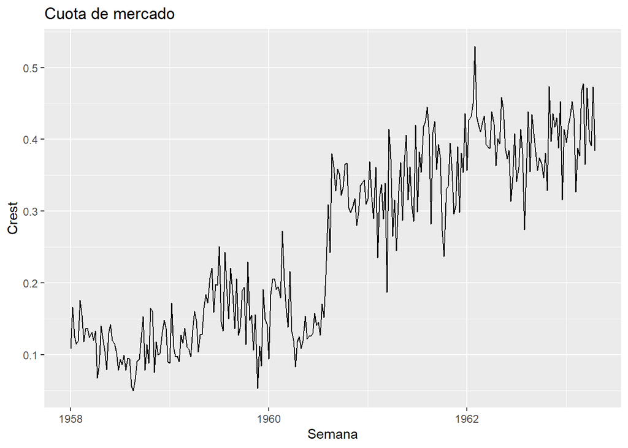

### Test de Dickey-Fuller

Realizamos el test para comprobar la existencia de estacionariedad en las series. Del p-valor del resultado concluimos su existencia.

```
##
##  Augmented Dickey-Fuller Test
##
## data:  zColgate
## Dickey-Fuller = -4.1783, Lag order = 6, p-value = 0.01
## alternative hypothesis: stationary
```

```
##
##  Augmented Dickey-Fuller Test
##
## data:  zCrest
## Dickey-Fuller = -3.4715, Lag order = 6, p-value = 0.04591
## alternative hypothesis: stationary
```

### Selección de train y test

```r
cOmit = 16

nObsColgate = length(zColgate)
nObsCrest = length(zCrest)
```

```r
trColgate <- window(zColgate, start = index(zColgate[1]),end = index(zColgate[nObsColgate - cOmit]))
trCrest <- window(zCrest, star = index(zCrest[1]), end = index(zCrest[nObsCrest - cOmit]))
```

### Modelo ARIMA

Para obtener el modelo autilizaremos autoarima. Ya realiza automaticamente las transformaciones necesarias para hacer el modelo estacionario. Lo realizaremos con el train.

```
## Series: trColgate
## ARIMA(0,1,1)(1,0,0)[52]
##
## Coefficients:
##           ma1    sar1
##       -0.7571  0.0232
## s.e.   0.0470  0.0682
##
## sigma^2 estimated as 0.00232:  log likelihood=418.63
## AIC=-831.25   AICc=-831.16   BIC=-820.58
##
## Training set error measures:
##                        ME       RMSE        MAE       MPE     MAPE      MASE
## Training set -0.002534821 0.04788855 0.03773876 -3.019377 12.77398 0.6038201
##                    ACF1
## Training set 0.05216089
```

```
## Series: trCrest
## ARIMA(0,1,1)
##
## Coefficients:
##           ma1
##       -0.6494
## s.e.   0.0448
##
## sigma^2 estimated as 0.002054:  log likelihood=434.08
## AIC=-864.15   AICc=-864.1   BIC=-857.04
##
## Training set error measures:
##                       ME       RMSE        MAE       MPE     MAPE      MASE
## Training set 0.003018071 0.04514444 0.03445351 -2.924537 17.27068 0.3800355
##                     ACF1
## Training set -0.04605961
```

#### Análisis de los residuos

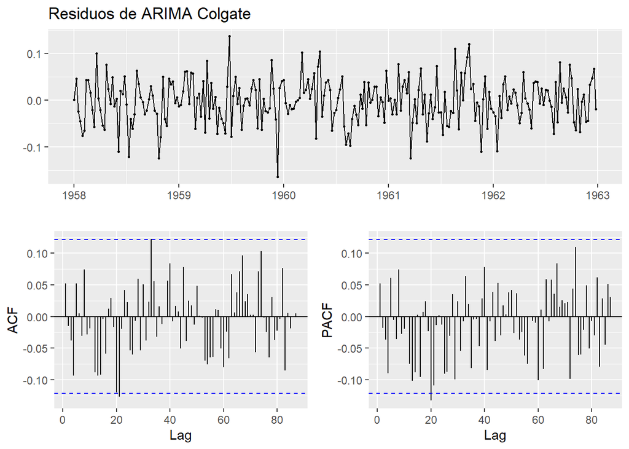

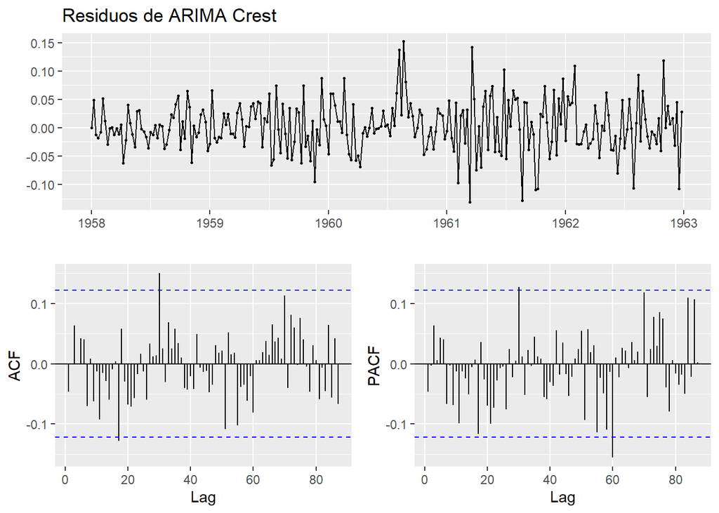

### Test de Ljung–Box

```
##
##  Box-Ljung test
##
## data:  fit_colgate$residuals
## X-squared = 1.1567, df = 2, p-value = 0.5608
```

```
##
##  Box-Ljung test
##
## data:  fit_crest$residuals
## X-squared = 1.6314, df = 2, p-value = 0.4423
```

En los resultados del test ambos valores son superiores al nivel de significación, por lo que no se puede rechazar la hipótesis nula, esto significa que no se rechaza que las observaciones se distribuyan de forma independiente.

### Predicción

Calculamos los valores predichos para las 16 semanas de 1963 con la función `forecast`.

```
##
## Forecast method: ARIMA(0,1,1)(1,0,0)[52]
##
## Model Information:
## Series: trColgate
## ARIMA(0,1,1)(1,0,0)[52]
##
## Coefficients:
##           ma1    sar1
##       -0.7571  0.0232
## s.e.   0.0470  0.0682
##
## sigma^2 estimated as 0.00232:  log likelihood=418.63
## AIC=-831.25   AICc=-831.16   BIC=-820.58
##
## Error measures:
##                        ME       RMSE        MAE       MPE     MAPE      MASE
## Training set -0.002534821 0.04788855 0.03773876 -3.019377 12.77398 0.6038201
##                    ACF1
## Training set 0.05216089
##
## Forecasts:
##          Point Forecast     Lo 80     Hi 80     Lo 95     Hi 95
## 1963.000      0.2669631 0.2052343 0.3286919 0.1725571 0.3613692
## 1963.019      0.2666376 0.2031138 0.3301615 0.1694863 0.3637890
## 1963.038      0.2646847 0.1994152 0.3299542 0.1648636 0.3645058
## 1963.058      0.2668236 0.1998539 0.3337933 0.1644023 0.3692449
## 1963.077      0.2657542 0.1971264 0.3343819 0.1607971 0.3707113
## 1963.096      0.2672654 0.1970186 0.3375121 0.1598323 0.3746985
## 1963.115      0.2678234 0.1959942 0.3396525 0.1579701 0.3776766
## 1963.135      0.2664516 0.1930741 0.3398292 0.1542304 0.3786729
## 1963.154      0.2670096 0.1921157 0.3419035 0.1524693 0.3815500
## 1963.173      0.2667074 0.1903272 0.3430875 0.1498940 0.3835207
## 1963.192      0.2673816 0.1895436 0.3452196 0.1483386 0.3864246
## 1963.212      0.2672654 0.1879963 0.3465345 0.1460338 0.3884970
## 1963.231      0.2667539 0.1860791 0.3474287 0.1433725 0.3901353
## 1963.250      0.2658239 0.1837675 0.3478803 0.1403295 0.3913183
## 1963.269      0.2660332 0.1826180 0.3494483 0.1384607 0.3936056
## 1963.288      0.2679396 0.1831875 0.3526917 0.1383225 0.3975567
```

```
##
## Forecast method: ARIMA(0,1,1)
##
## Model Information:
## Series: trCrest
## ARIMA(0,1,1)
##
## Coefficients:
##           ma1
##       -0.6494
## s.e.   0.0448
##
## sigma^2 estimated as 0.002054:  log likelihood=434.08
## AIC=-864.15   AICc=-864.1   BIC=-857.04
##
## Error measures:
##                       ME       RMSE        MAE       MPE     MAPE      MASE
## Training set 0.003018071 0.04514444 0.03445351 -2.924537 17.27068 0.3800355
##                     ACF1
## Training set -0.04605961
##
## Forecasts:
##          Point Forecast     Lo 80     Hi 80     Lo 95     Hi 95
## 1963.000      0.3958305 0.3377518 0.4539092 0.3070067 0.4846543
## 1963.019      0.3958305 0.3342850 0.4573760 0.3017048 0.4899563
## 1963.038      0.3958305 0.3310033 0.4606577 0.2966859 0.4949751
## 1963.058      0.3958305 0.3278800 0.4637810 0.2919092 0.4997519
## 1963.077      0.3958305 0.3248940 0.4667670 0.2873425 0.5043185
## 1963.096      0.3958305 0.3220288 0.4696322 0.2829605 0.5087005
## 1963.115      0.3958305 0.3192707 0.4723903 0.2787424 0.5129186
## 1963.135      0.3958305 0.3166086 0.4750525 0.2746710 0.5169900
## 1963.154      0.3958305 0.3140330 0.4776280 0.2707321 0.5209290
## 1963.173      0.3958305 0.3115362 0.4801249 0.2669134 0.5247476
## 1963.192      0.3958305 0.3091111 0.4825499 0.2632047 0.5284563
## 1963.212      0.3958305 0.3067521 0.4849089 0.2595969 0.5320642
## 1963.231      0.3958305 0.3044540 0.4872070 0.2560822 0.5355789
## 1963.250      0.3958305 0.3022122 0.4894488 0.2526537 0.5390073
## 1963.269      0.3958305 0.3000229 0.4916381 0.2493054 0.5423556
## 1963.288      0.3958305 0.2978825 0.4937785 0.2460320 0.5456290
```

Graficamos el resultado de la predicción.

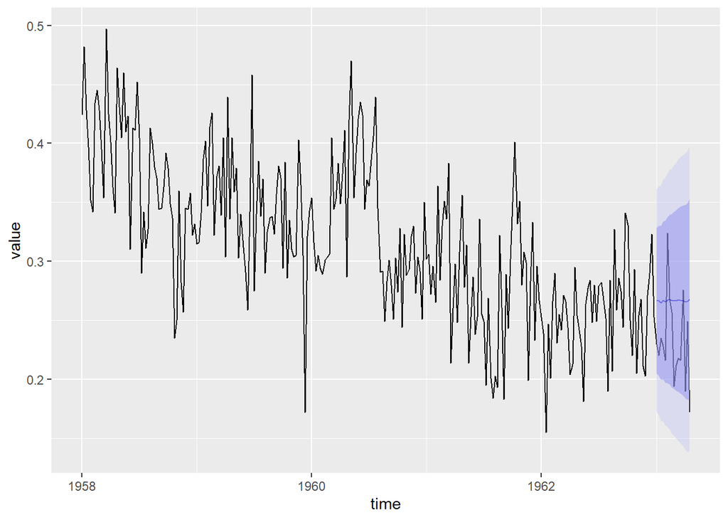

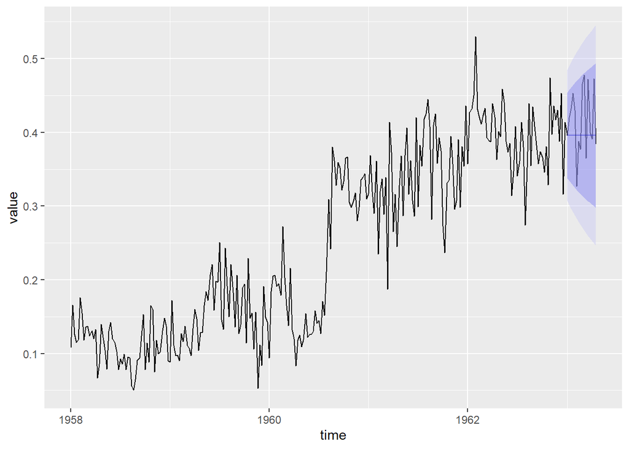

### Outliers

Localizamos los outliers.

Hay tres outliers aditivos en la serie de Crest, en la posicion 135 debido al comunicado del Consejo de Terapéutica Dental de la American Dental Association, y en los puntos 136 y 138, muy próximos.

```
## [1] "No AO detected"
```

```
##               [,1]       [,2]       [,3]
## ind     135.000000 136.000000 138.000000
## lambda2   3.918954   4.372891   4.005427
```

```
## [1] "No IO detected"
```

```
## [1] "No IO detected"
```

### ARIMAX

```
##
## Call:
## arimax(x = as.double(zColgate), order = c(0, 1, 1), method = "ML", xtransf = data.frame(A60_step = 1 *
##     (seq(zColgate)), A60_pulse = 1 * (seq(zColgate))), transfer = list(c(0,
##     0), c(1, 0)))
##
## Coefficients:
```

```
##           ma1  A60_step-MA0  A60_pulse-AR1  A60_pulse-MA0
##       -0.7730        -4e-04              0        -0.0004
## s.e.   0.0455           NaN            NaN         0.0072
##
## sigma^2 estimated as 0.002256:  log likelihood = 447.31,  aic = -886.61
```

```r
arimax_crest <- arimax(as.double(zCrest),
                       order = c(0,1,1),
                       xtransf = data.frame(A60_step = 1*(seq(zCrest) >= 135 ),
                                            A60_pulse = 1*(seq(zCrest) )),
                       xreg = data.frame(A60_3 = 1*(seq(zCrest) == 136),
                                         A60_3 = 1*(seq(zCrest) == 138)),
                       transfer = list(
                         c(0,0),
                         c(0,0)
                       ),
                       method = 'ML')
arimax_crest
```

```
##
## Call:
## arimax(x = as.double(zCrest), order = c(0, 1, 1), xreg = data.frame(A60_3 = 1 *
##     (seq(zCrest) == 136), A60_3 = 1 * (seq(zCrest) == 138)), method = "ML",
##     xtransf = data.frame(A60_step = 1 * (seq(zCrest) >= 135), A60_pulse = 1 *
##         (seq(zCrest))), transfer = list(c(0, 0), c(0, 0)))
##
## Coefficients:
##           ma1   A60_3  A60_3.1  A60_step-MA0  A60_pulse-MA0
##       -0.7674  0.0205   0.0766        0.1346          5e-04
## s.e.   0.0476  0.0436   0.0420        0.0318          6e-04
##
## sigma^2 estimated as 0.001899:  log likelihood = 470.97,  aic = -931.94
```

Calculamos de nuevo los outliers y comprobamos que ya no existen.

```
## [1] "No AO detected"
```

```
## [1] "No IO detected"
```

```
## [1] "No AO detected"
```

```
## [1] "No IO detected"
```

### Función de transferencia

```
##
## Call:
## arimax(x = as.double(zColgate), order = c(0, 1, 1), include.mean = TRUE, method = "ML",
##     xtransf = zCrest, transfer = list(c(0, 0)))
##
## Coefficients:
##           ma1  xtransf-MA0
##       -0.8381      -0.4884
## s.e.   0.0346       0.0530
##
## sigma^2 estimated as 0.001751:  log likelihood = 481.99,  aic = -959.97
```

```
##
## Call:
## arimax(x = as.double(zColgate), order = c(0, 1, 1), include.mean = TRUE, method = "ML",
##     xtransf = zCrest, transfer = list(c(0, 0)))
##
## Coefficients:
##           ma1  xtransf-MA0
##       -0.8381      -0.4884
## s.e.   0.0346       0.0530
##
## sigma^2 estimated as 0.001751:  log likelihood = 481.99,  aic = -959.97
##
## Training set error measures:
##                       ME      RMSE        MAE       MPE     MAPE      MASE
## Training set -0.00136496 0.0417676 0.03229819 -2.196369 10.97291 0.6993702
##                    ACF1
## Training set 0.06132245
```

```
##
## Call:
## arimax(x = as.double(zCrest), order = c(0, 1, 1), include.mean = TRUE, method = "ML",
##     xtransf = zColgate, transfer = list(c(0, 0)))
##
## Coefficients:
##           ma1  xtransf-MA0
##       -0.7129      -0.4350
## s.e.   0.0415       0.0526
##
## sigma^2 estimated as 0.001653:  log likelihood = 490.12,  aic = -976.23
```

```
##
## Call:
## arimax(x = as.double(zCrest), order = c(0, 1, 1), include.mean = TRUE, method = "ML",
##     xtransf = zColgate, transfer = list(c(0, 0)))
##
## Coefficients:
##           ma1  xtransf-MA0
##       -0.7129      -0.4350
## s.e.   0.0415       0.0526
##
## sigma^2 estimated as 0.001653:  log likelihood = 490.12,  aic = -976.23
##
## Training set error measures:
##                       ME       RMSE        MAE       MPE     MAPE      MASE
## Training set 0.002513135 0.04058777 0.03171038 -2.585475 16.42409 0.7452021
##                     ACF1
## Training set -0.02762795
```